# R introduction to machine learning

기계학습 소개-SEHnR, basic step 1

# 1 명명

1. outcome : 예측하고 싶은 것
2. features: 예측에 사용되는 것

| outcome | feature<sub>1</sub> | feature<sub>2</sub> | … | feature<sub>n</sub> |
| --- | --- | --- | --- | --- |
| Y<sub>1,1</sub> | Y<sub>1,2</sub> | Y<sub>1,3</sub> | … | Y<sub>1,n</sub> |
| Y<sub>2,1</sub> | Y<sub>2,2</sub> | Y<sub>2,3</sub> | … | Y<sub>2,n</sub> |
| : | : | : | … | : |
| Y<sub>i,1</sub> | Y<sub>i,2</sub> | Y<sub>i,3</sub> | … | Y<sub>i,n</sub> |

```r
library(dplyr)
library(knitr)
library(kableExtra)
library(dslabs)
library(caret)
data(heights)
```

Outcome (y)과 Predictors(feature) (x)를 정의해 보자

```r
y<-heights$sex     # outcome
x<-heights$height  # feature
```

# 2 Training and Test set

```r
set.seed(2007, sample.kind = 'Rounding')
library(caret)
test_index <-createDataPartition(y, times=1, p=0.5, list=FALSE)
```

`set.seed`는 무작위 추출시 값을 고정한 것이고, `times`는 얼마나 많은 표본을 `p`의 확률로 뽑을 것인가이다.

```r
test_set <- heights[+test_index, ]
train_set <-heights[-test_index,]
```

로 test_set과 train_set을 구분한다. 여기서 **train_set** 만을 이용하여 예측 모데릉ㄹ 만들고, **test_set**에서 예측정도를 확인할 것이다.

# 3 Overall accuracy

정확도 검사를 위해 우선 결과를 단순 무작위로 예측해보자 즉,

```r
y_hat <-sample(c("Male", "Female"), length(test_index), replace=TRUE) %>% factor(levels=levels(test_set$sex))
```

`sample`명령으로 남/녀 중에 test_index 갯수 만큰, `replace=TRUE` 복원 추출을 하였다. 이후 `%>%`로 후속 조치를 하였는데, 남/녀의 수준을 test_set$sex의 수준 값과 동일하게 맞추었다(이래야 비교할 때 오류가 않남)

전체적 정확도는

```r
mean(y_hat==test_set$sex)
```

```
## [1] 0.5085714
```

당연히 50%정도의 정확도를 갖는다.

남자와 여자의 키를 구별해보자

```r
heights %>% group_by(sex) %>% summarize(mean(height), sd(height)) %>%kable()%>%kable_styling(full_width = F)
```

| sex | mean(height) | sd(height) |
| --- | --- | --- |
| Female | 64.93942 | 3.760656 |
| Male | 69.31475 | 3.611024 |

62인치 보다 큰 사람을 남자로 하여 예측해보자.

```r
library(purrr)
```

```r
cutoff <- seq(61, 70)
accuracy <- map_dbl(cutoff, function(x){
  y_hat <- ifelse(train_set$height > x, "Male", "Female") %>%
    factor(levels = levels(test_set$sex))
  mean(y_hat == train_set$sex)
})
```

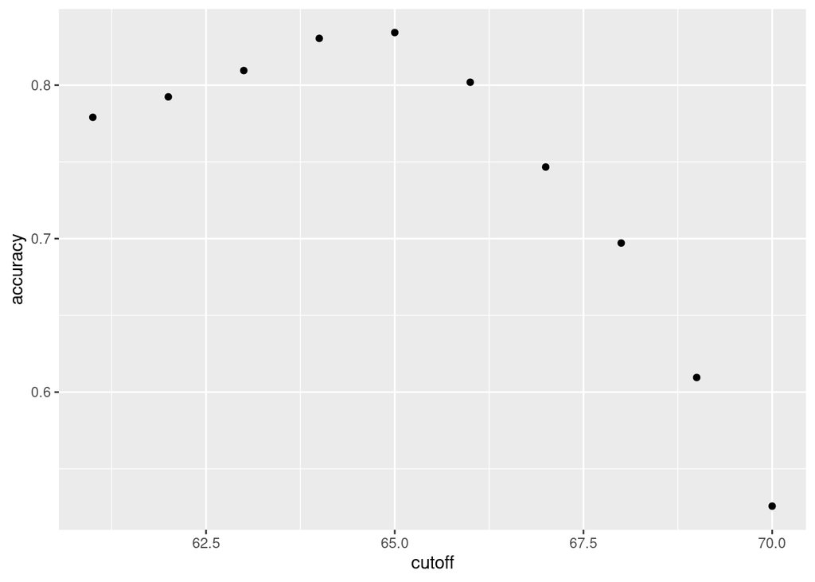

```r
qplot(cutoff, accuracy)
```

민감도 특이도도 조사해보 쉽게 하는 방법은 `confusionMatrix`를 사용하는 것이다.

```r
y_hat <- ifelse(test_set$height > 64, "Male", "Female") %>%
  factor(levels = levels(test_set$sex))
y_hat <- factor(y_hat)
```

여기서 y_hat에height가 64보다 클때, 남자, 아니면 여자로 값을 준후, 아래의 confusionMatrix에서 test_set의 sex 값과 일치되는지 여부를 보는 것이다.

```r
cm <-confusionMatrix(data=y_hat, reference=test_set$sex)
```

2*2 표로 나타내 보면

```r
cm$table
```

```
##           Reference
## Prediction Female Male
##     Female     53   27
##     Male       66  379
```

|  | Actually.Positive | Actually.Negative |
| --- | --- | --- |
| Predicted positive | True positives (TP) | False positives (FP) |
| Predicted negative | False negatives (FN) | True negatives (TN) |

|  | Actually Positive | Actually Negative |
| --- | --- | --- |
| Predicted positive | True positives (TP) | False positives (FP) |
| Predicted negative | False negatives (FN) | True negatives (TN) |

기본 산출 값들을 나열해 보면 아래와 같다.

```r
cm$overall
```

```
##       Accuracy          Kappa  AccuracyLower  AccuracyUpper   AccuracyNull
##   8.228571e-01   4.285129e-01   7.874558e-01   8.545736e-01   7.733333e-01
## AccuracyPValue  McnemarPValue
##   3.232430e-03   8.134028e-05
```

몇가지 용어를 정리해 보면

[output not shown]

# 4 F<sub>1</sub> score and Balanced Accuracy

```r
library(caret)
F_meas(data=y_hat, reference=test_set$sex)
```

```
## [1] 0.5326633
```

cutoff를 바꿔가면서 F_1을 구해보면 ’cutoff=65’가 결정된다.

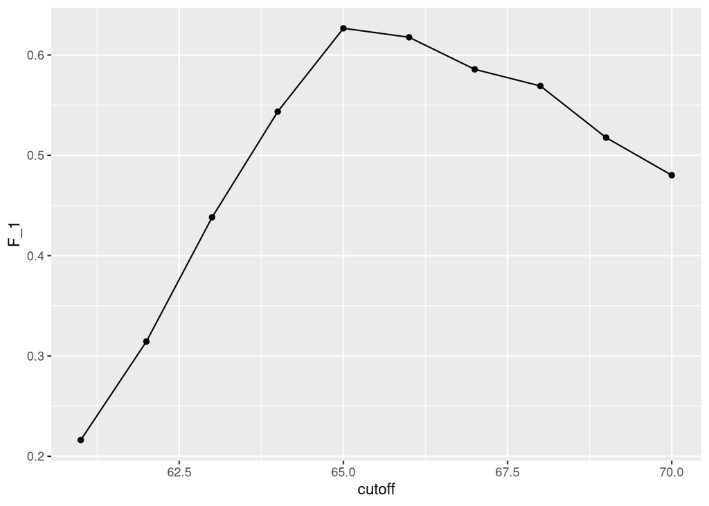

```r
F_1 <-map_dbl(cutoff, function(x){
  y_hat <-ifelse(train_set$height >x, "Male", "Female") %>% factor(levels=levels(test_set$sex))
  F_meas(data=y_hat, reference=factor(train_set$sex))
})
qplot(cutoff, F_1)+geom_line()
```

# 5 연속변소에서 Loss function

지금가지 2분형 변수에 대해서 민간도, 특이도, 정확도, F_1을 연습했다. 그러나 outcome이 연속변수 일경우에는 `loss function`을 사용할 것이다. 가장 많이 사용되는 `loss fucntion`은 $\hat{y}$ 와 $y$ 값의 차이를 줄여주는 방법을 사용할 수 있다.